# EP09-respuesta-equipo-8

Ahora viendo el modelo 3D con los datos de prueba, podemos observar que las predicciones se distribuyen de manera similar a los datos de entrenamiento, lo que indica que el modelo es capaz de generalizar bien a nuevos datos.

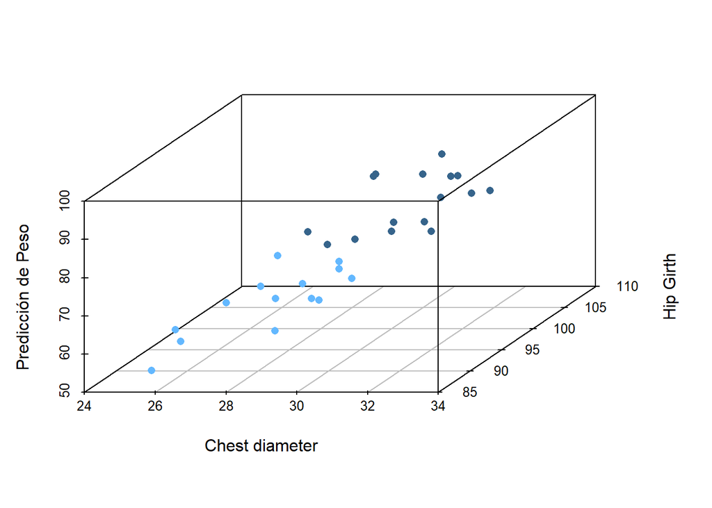

```r
# Predecir usando el modelo entrenado
DatosPredMulti <- datosPrueba[, c("Hip.Girth", "Forearm.Girth", "Height", "Navel.Girth", "Chest.diameter")]
pred_multi <- predict(modelo_opt, newdata = DatosPredMulti)

# Unir predicciones con los datos de prueba
datosPredMulti <- cbind(datosPrueba, pred_multi)

# Visualizar predicciones en 3D
if (all(c("Chest.diameter", "Hip.Girth") %in% colnames(datosPredMulti))) {
  i_color <- 1 + (pred_multi > mean(pred_multi))
  scatterplot3d(x = datosPredMulti$Chest.diameter,
                y = datosPredMulti$Hip.Girth,
                z = datosPredMulti$pred_multi,
                color = c("steelblue1", "steelblue4")[i_color],
                pch = 16, angle = 50,
                xlab = "Chest diameter",
                ylab = "Hip Girth",
                zlab = "Predicción de Peso")
}
```

Ahora, evaluaremos la confiabilidad del modelo RLM.

```r
#1. La variable de respuesta debe ser cuantitativa y continua, sin restricciones para su variabilidad
str(DatosModeloRLM$Weight)
```

```
##  num [1:70] 84.1 90.5 69.1 66.2 62.3 ...
```

La variable `Weight` es cuantitativa y continua, ya que representa el peso en kilogramos, lo cual es una medida numérica sin restricciones.

```r
#2. Las variables predictoras deben ser cuantitativas o dicotomicas
str(DatosModeloRLM[, c("Hip.Girth", "Forearm.Girth", "Height", "Navel.Girth", "Chest.diameter")])
```

```
## 'data.frame':    70 obs. of  5 variables:
##  $ Hip.Girth     : num  99.9 101.7 95.4 92.2 87.6 ...
##  $ Forearm.Girth : num  32 29 27.5 26.9 29.2 30.5 25.5 26.2 30.6 28.3 ...
##  $ Height        : num  178 188 173 173 170 ...
##  $ Navel.Girth   : num  85.7 91.9 83 75.9 82.3 ...
##  $ Chest.diameter: num  29.9 32.6 27.9 30.9 29 33.3 25.9 30 34.3 32.8 ...
```

Las variables predictoras son cuantitativas, ya que representan medidas físicas (circunferencias y altura) en centímetros, lo cual es una medida numérica continua. No hay variables dicotómicas en este conjunto de datos.

```r
#3. Los predictores deben tener algún grado de variabilidad (su varianza no debe ser igual a cero). En otras palabras no pueden ser constantes.
apply(DatosModeloRLM[, c("Hip.Girth", "Forearm.Girth", "Height", "Navel.Girth", "Chest.diameter")],2, var)
```

```
##      Hip.Girth  Forearm.Girth         Height    Navel.Girth Chest.diameter
##      45.120489       3.266768      52.993807      92.006716       4.624563
```

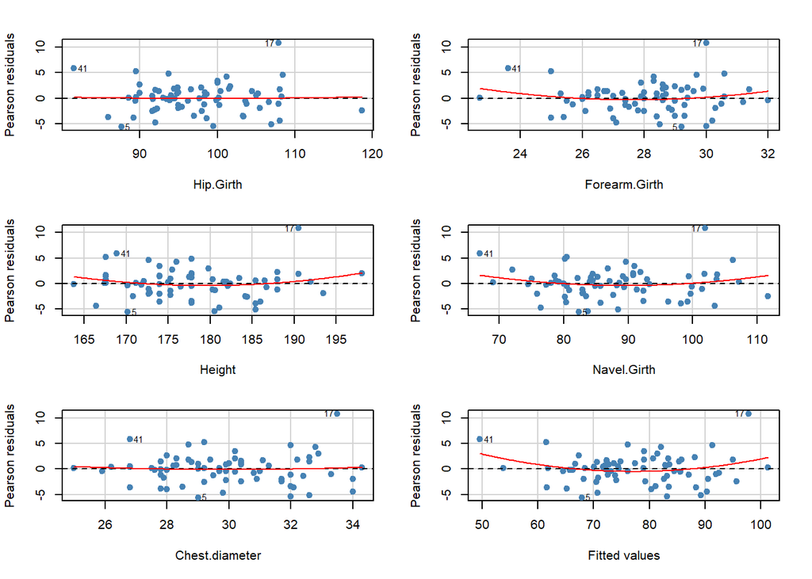

```
##                Test stat Pr(>|Test stat|)
## Hip.Girth         0.1324          0.89512
## Forearm.Girth     1.1861          0.24002
## Height            1.3770          0.17339
## Navel.Girth       1.3410          0.18474
## Chest.diameter    0.3433          0.73252
## Tukey test        2.0188          0.04351 *
## ---
## Signif. codes:  0 '***' 0.001 '**' 0.01 '*' 0.05 '.' 0.1 ' ' 1
```

```r
residualPlots(modelo_opt,
              terms = ~ Hip.Girth + Forearm.Girth + Height + Navel.Girth + Chest.diameter,
              id = list(method= "r", n = 3, cex = 0.7),
              col = "steelblue", pch = 19, col.quad= "red")
```

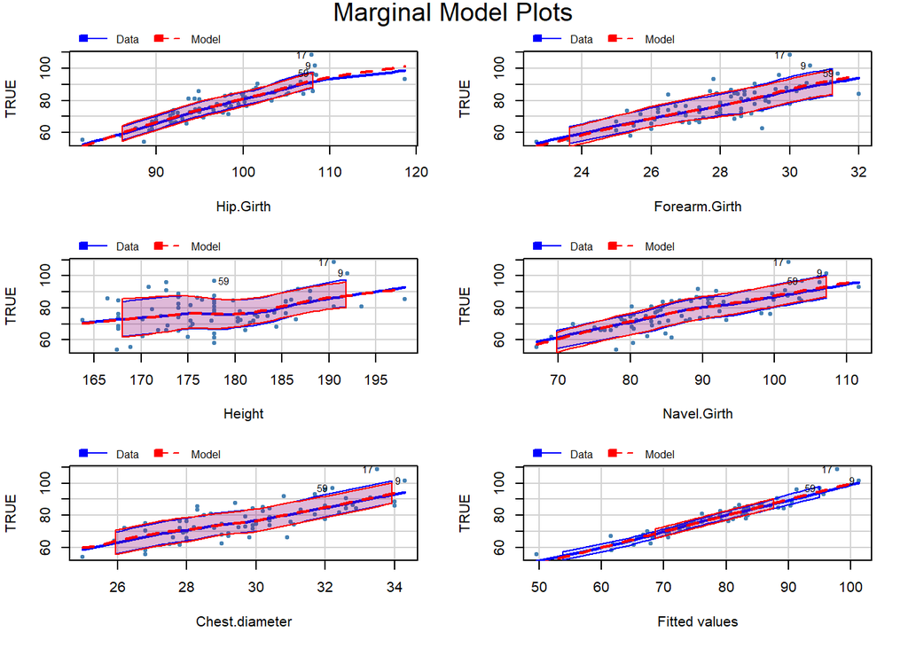

```r
marginalModelPlots(modelo_opt, sd = TRUE, terms =  ~ Hip.Girth + Forearm.Girth + Height + Navel.Girth + Chest.diameter, id = list(method = "r", n = 3, cex = 0.7, location = "lr"), col = "steelblue", pch = 20, col.quad= c("steelblue", "red"))
```

```r
#6. La variabilidad de los residuos debe ser aproximadamente constante (homoestacidad)
ncvTest(modelo_opt)
```

```
## Non-constant Variance Score Test
## Variance formula: ~ fitted.values
## Chisquare = 3.212092, Df = 1, p = 0.073096
```

```r
#7. Los residuos deben ser independientes
durbinWatsonTest(modelo_opt)
```

```
##  lag Autocorrelation D-W Statistic p-value
##    1      -0.1101464       2.19453   0.396
##  Alternative hypothesis: rho != 0
```

La prueba de Durbin-Watson indica que los residuos son independientes, ya que el valor de la estadística es cercano a 2, lo que sugiere que no hay autocorrelación significativa entre los residuos del modelo.

```r
#8. No debe existir multicolinealidad
vif(modelo_opt)
```

```
##      Hip.Girth  Forearm.Girth         Height    Navel.Girth Chest.diameter
##       4.937343       1.738633       1.058874       3.466465       2.244815
```

Si bien el VIF de `Hip.Girth` es 4.937343 lo que indica que hay cierta multicolinealidad, no es lo suficientemente alto como para considerarlo problemático. En general, un VIF por debajo de 5 se considera aceptable, y por encima de 10 indica problemas serios de multicolinealidad. Por lo tanto, en este caso, la multicolinealidad no es un problema significativo.

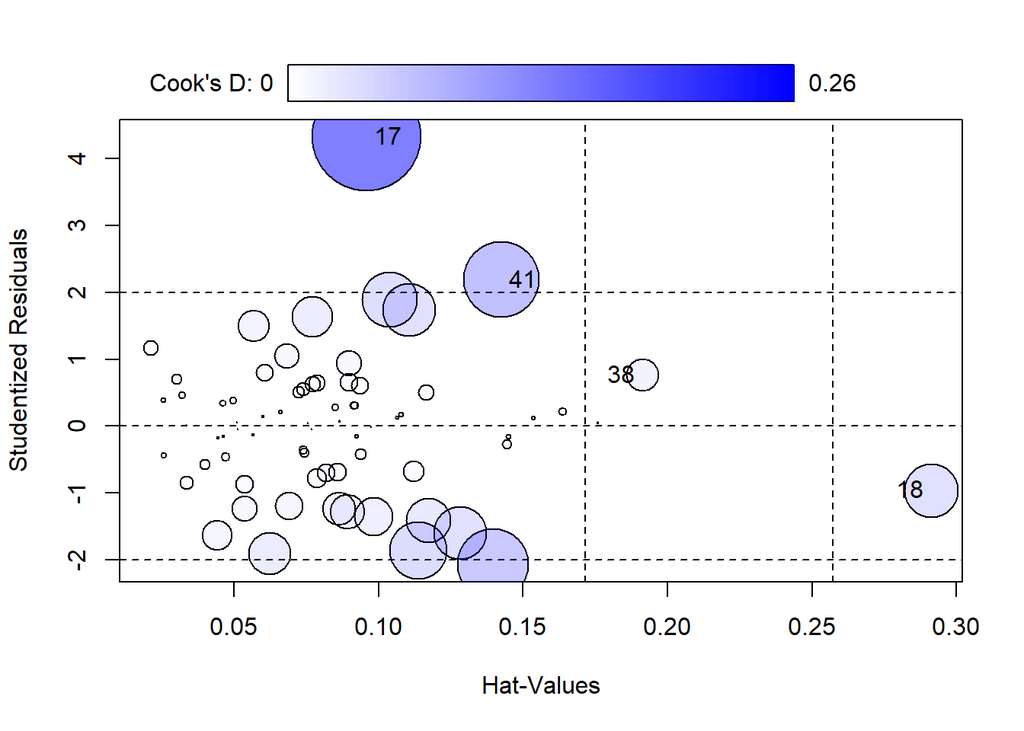

```
##       StudRes       Hat      CookD
## 17  4.3295208 0.0959650 0.25964270
## 18 -0.9608745 0.2911842 0.06329034
## 38  0.7685360 0.1912640 0.02343098
## 41  2.1880272 0.1426224 0.12531424
```

```r
#9. Las estimaciones de los coeficientes del modelo no deben estar alterados por unas pocas observaciones influyentes.
influencePlot(modelo_opt, id.method = "identify")
```

# Calidad predictiva del RLM

```r
formula <- formula(Weight ~ Hip.Girth, Forearm.Girth, Height, Navel.Girth, Chest.diameter)
ent <- train(
  formula,
  data = DatosModeloRLM,
  method = "lm",
  trControl = trainControl(method = "cv", number = 10)
)

modelofRLM <- ent[["finalModel"]]
print(summary(modelofRLM))
```

```
##
## Call:
## lm(formula = .outcome ~ ., data = dat)
##
## Residuals:
##      Min       1Q   Median       3Q      Max
## -13.9294  -3.0165  -0.1108   2.2253  16.6695
##
## Coefficients:
##             Estimate Std. Error t value Pr(>|t|)
## (Intercept) -59.9180     8.7476   -6.85 2.64e-09 ***
## Hip.Girth     1.4073     0.0894   15.74  < 2e-16 ***
## ---
## Signif. codes:  0 '***' 0.001 '**' 0.01 '*' 0.05 '.' 0.1 ' ' 1
##
## Residual standard error: 4.988 on 68 degrees of freedom
## Multiple R-squared:  0.7847, Adjusted R-squared:  0.7815
## F-statistic: 247.8 on 1 and 68 DF,  p-value: < 2.2e-16
```

```r
print(ent[["resample"]])
```

```
##        RMSE  Rsquared      MAE Resample
## 1  3.419985 0.8630603 3.111579   Fold01
## 2  6.118196 0.9030482 5.077546   Fold02
## 3  3.892855 0.8668932 3.063536   Fold03
## 4  7.638060 0.8747750 5.423968   Fold04
## 5  4.855965 0.8325902 3.869989   Fold05
## 6  6.890810 0.8604504 4.259668   Fold06
## 7  2.948329 0.9292604 2.293420   Fold07
## 8  4.139730 0.7378336 2.602290   Fold08
## 9  4.135947 0.6949671 3.264364   Fold09
## 10 5.731127 0.8478753 4.651481   Fold10
```

```r
print(ent[["results"]])
```

```
##   intercept   RMSE  Rsquared      MAE   RMSESD RsquaredSD    MAESD
## 1      TRUE 4.9771 0.8410754 3.761784 1.554676 0.07180446 1.064764
```